# Dictionary INS_Inschrijvingen_synthetic

Autogenerated data summary from dataReporter

2024-03-27 18:28:10.099907

# Data report overview

The dataset examined has the following dimensions:

| Feature | Result |
| --- | --- |
| Number of observations | 21507 |
| Number of variables | 261 |

# Codebook summary table

| Label | Variable | Class | # unique values | Missing | Description |
| --- | --- | --- | --- | --- | --- |
|  | **INS_Instelling** | character | 1 | 0.00 % |  |
|  | **INS_Versie_1CHO_jaar** | numeric | 1 | 0.00 % |  |
|  | **INS_Studentnummer** | numeric | 7693 | 0.00 % |  |
|  | **INS_Inschrijvingsjaar** | numeric | 12 | 0.00 % |  |
|  | **INS_Inschrijvingsjaar_EOI** | numeric | 13 | 0.00 % |  |
|  | **INS_Studierichting_SAP_numeriek** | numeric | 4 | 0.00 % |  |
|  | **INS_Soort_inschrijving_1CHO_code** | numeric | 3 | 0.00 % |  |
|  | **INS_Soort_inschrijving_actuele_instelling** | numeric | 3 | 0.00 % |  |
|  | **INS_Opleidingsfase_actueel_code** | character | 2 | 0.00 % |  |
|  | **INS_Indicatie_actief_op_peildatum_code** | numeric | 3 | 0.00 % |  |
|  | **OPL_Code_in_jaar** | numeric | 4 | 0.00 % |  |
|  | **INS_Opleidingsnaam_2002** | character | 4 | 0.00 % |  |
|  | **INS_Indicatie_eerste_jaars_opleiding** | numeric | 5 | 0.00 % |  |
|  | **INS_Indicatie_eerste_jaars_instelling** | numeric | 5 | 0.00 % |  |
|  | **INS_Indicatie_eerste_jaars_opleiding_en_instelling** | numeric | 3 | 0.00 % |  |
|  | **INS_Eerste_jaar_opleiding_en_instelling** | numeric | 13 | 0.00 % |  |
|  | **INS_Eerste_jaar_hoger_onderwijs** | numeric | 41 | 0.00 % |  |
|  | **INS_Eerste_jaar_soort_hoger_onderwijs** | numeric | 40 | 0.00 % |  |
|  | **INS_Vooropleiding_voor_HO_code** | numeric | 25 | 0.00 % |  |
|  | **INS_Vooropleiding_voor_HO_cat** | character | 6 | 1.98 % |  |
|  | **INS_Vooropleiding_voor_HO_jaar** | numeric | 42 | 2.06 % |  |
|  | **INS_Vooropleiding_voor_HO_BRIN** | character | 509 | 21.83 % |  |
|  | **INS_Vooropleiding_binnen_HO_code** | numeric | 45 | 0.00 % |  |
|  | **INS_Vooropleiding_binnen_HO_cat** | character | 8 | 58.39 % |  |
|  | **INS_Vooropleiding_binnen_HO_jaar** | numeric | 35 | 58.39 % |  |
|  | **INS_Vooropleiding_binnen_HO_BRIN** | character | 52 | 58.98 % |  |
|  | **INS_Hoogste_vooropleiding_code_1CHO** | numeric | 63 | 0.00 % |  |
|  | **INS_Hoogste_vooropleiding_cat** | character | 12 | 1.78 % |  |
|  | **INS_Hoogste_vooropleiding_jaar_1CHO** | numeric | 38 | 1.86 % |  |
|  | **INS_Hoogste_vooropleiding_BRIN_1CHO** | character | 452 | 19.19 % |  |

[output cut: 231 more lines]

# Variable list

## INS_Instelling

- The variable only takes one (non-missing) value: "VU". The variable contains 0 % missing observations.

## INS_Versie_1CHO_jaar

- The variable only takes one (non-missing) value: "2021". The variable contains 0 % missing observations.

## INS_Studentnummer

| Feature | Result |
| --- | --- |
| Variable type | numeric |
| Number of missing obs. | 0 (0 %) |
| Number of unique values | 7693 |
| Median | 67466 |
| 1st and 3rd quartiles | 44430; 89711 |
| Min. and max. | 273; 129184 |

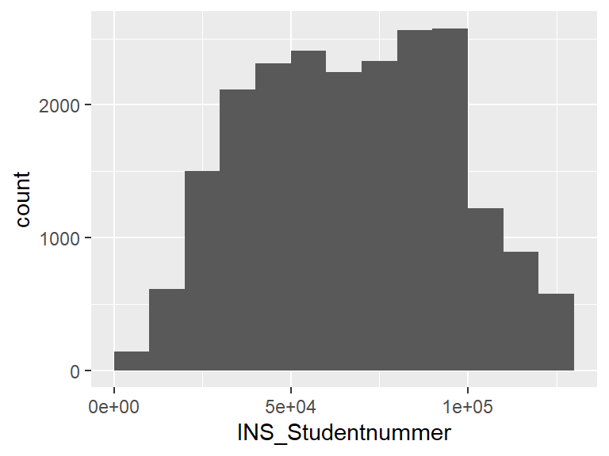

## INS_Inschrijvingsjaar

| Feature | Result |
| --- | --- |
| Variable type | numeric |
| Number of missing obs. | 0 (0 %) |
| Number of unique values | 12 |
| Median | 2018 |
| 1st and 3rd quartiles | 2014; 2020 |
| Min. and max. | 2011; 2022 |

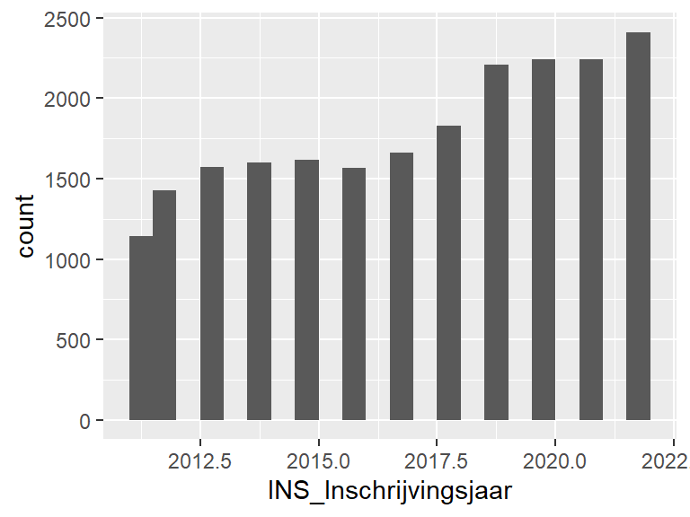

## INS_Inschrijvingsjaar_EOI

| Feature | Result |
| --- | --- |
| Variable type | numeric |
| Number of missing obs. | 0 (0 %) |
| Number of unique values | 13 |
| Median | 2017 |
| 1st and 3rd quartiles | 2013; 2019 |
| Min. and max. | 2010; 2022 |

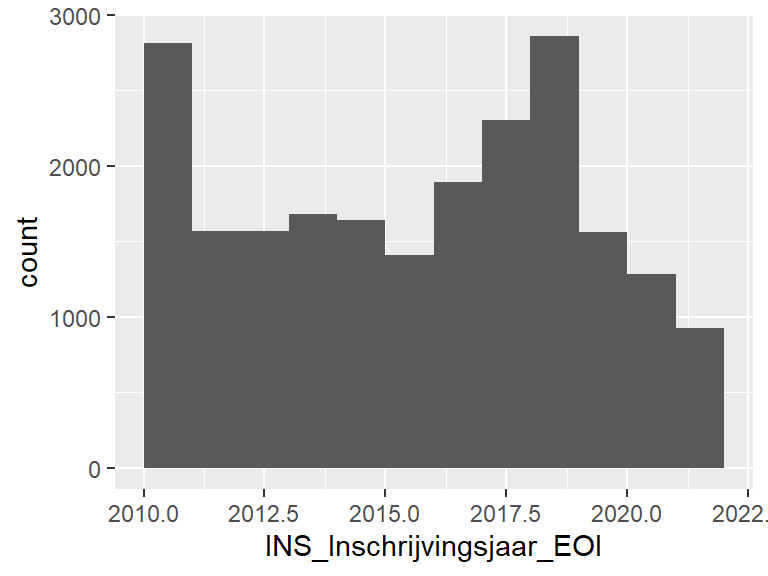

## INS_Studierichting_SAP_numeriek

| Feature | Result |
| --- | --- |
| Variable type | numeric |
| Number of missing obs. | 0 (0 %) |
| Number of unique values | 4 |
| Median | 50050845 |
| 1st and 3rd quartiles | 50050845; 50050846 |
| Min. and max. | 50050845; 50067800 |

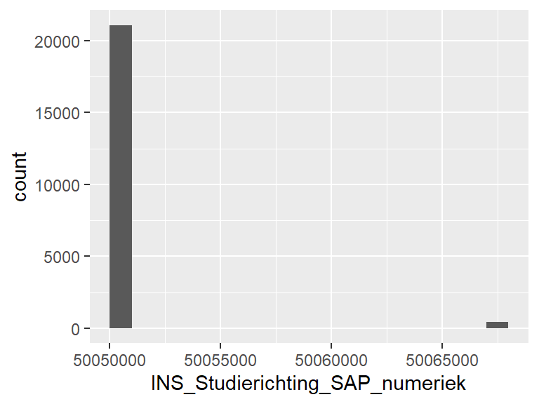

## INS_Soort_inschrijving_1CHO_code

| Feature | Result |
| --- | --- |
| Variable type | numeric |
| Number of missing obs. | 0 (0 %) |
| Number of unique values | 3 |
| Median | 1 |
| 1st and 3rd quartiles | 1; 1 |
| Min. and max. | 1; 3 |

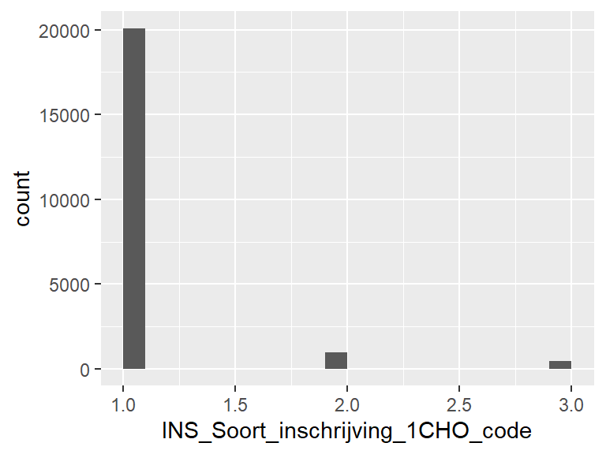

## INS_Soort_inschrijving_actuele_instelling

| Feature | Result |
| --- | --- |
| Variable type | numeric |
| Number of missing obs. | 0 (0 %) |
| Number of unique values | 3 |
| Median | 1 |
| 1st and 3rd quartiles | 1; 1 |
| Min. and max. | 1; 3 |

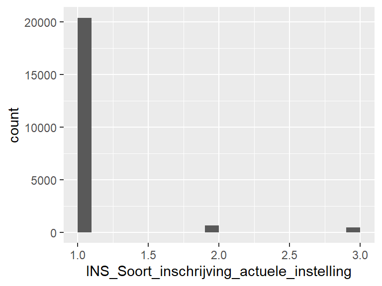

## INS_Opleidingsfase_actueel_code

| Feature | Result |
| --- | --- |
| Variable type | character |
| Number of missing obs. | 0 (0 %) |
| Number of unique values | 2 |
| Mode | “B” |

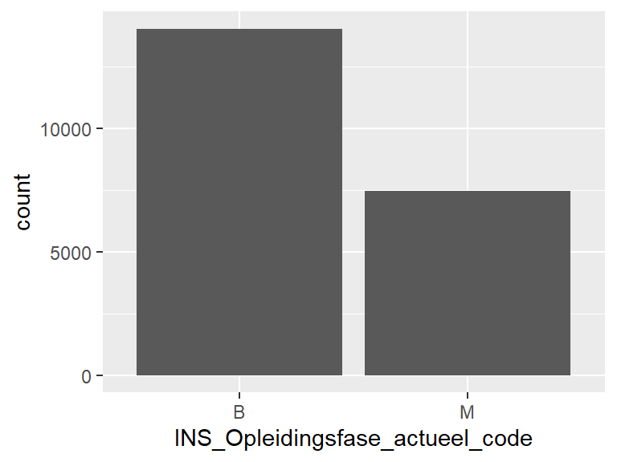

- Observed factor levels: "B", "M".

## INS_Indicatie_actief_op_peildatum_code

| Feature | Result |
| --- | --- |
| Variable type | numeric |
| Number of missing obs. | 0 (0 %) |
| Number of unique values | 3 |
| Median | 1 |
| 1st and 3rd quartiles | 1; 1 |
| Min. and max. | 1; 3 |

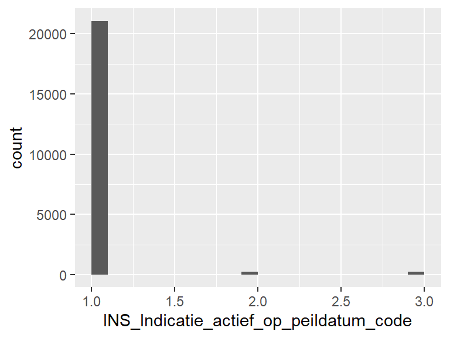

## OPL_Code_in_jaar

| Feature | Result |
| --- | --- |
| Variable type | numeric |
| Number of missing obs. | 0 (0 %) |
| Number of unique values | 4 |
| Median | 50000 |
| 1st and 3rd quartiles | 50000; 60000 |
| Min. and max. | 50000; 60002 |

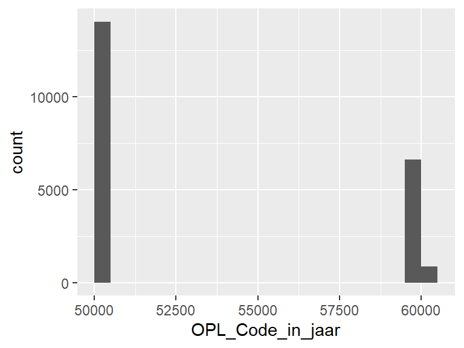

## INS_Opleidingsnaam_2002

| Feature | Result |
| --- | --- |
| Variable type | character |
| Number of missing obs. | 0 (0 %) |
| Number of unique values | 4 |
| Mode | “B Wizardry” |

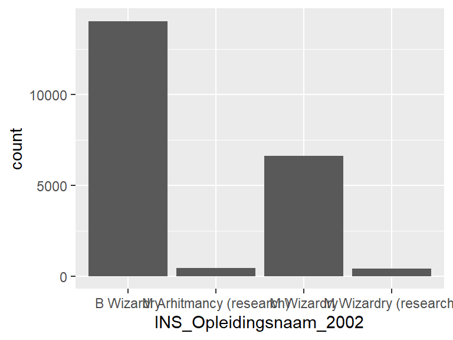

- Observed factor levels: "B Wizardry", "M Arhitmancy (research)", "M Wizardry", "M Wizardry (research)".

## INS_Indicatie_eerste_jaars_opleiding

| Feature | Result |
| --- | --- |
| Variable type | numeric |
| Number of missing obs. | 0 (0 %) |
| Number of unique values | 5 |
| Median | 2 |
| 1st and 3rd quartiles | 1; 2 |
| Min. and max. | 1; 5 |

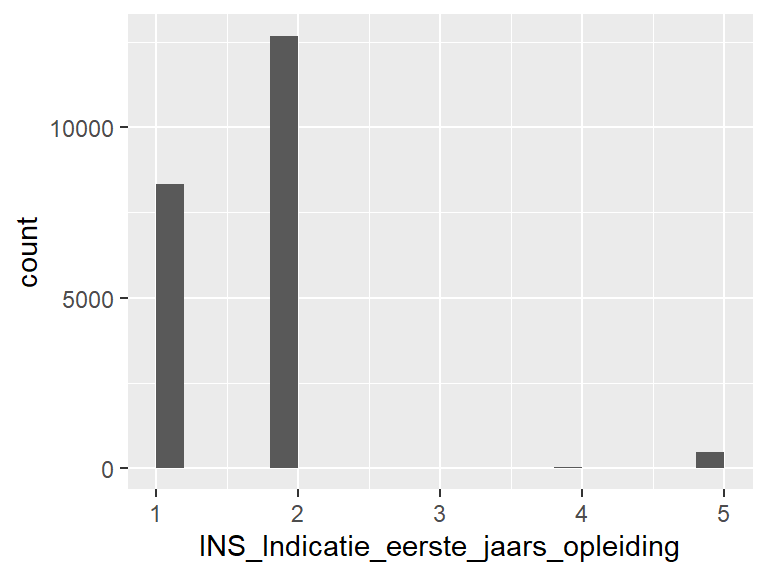

## INS_Indicatie_eerste_jaars_instelling

| Feature | Result |
| --- | --- |
| Variable type | numeric |
| Number of missing obs. | 0 (0 %) |
| Number of unique values | 5 |
| Median | 2 |
| 1st and 3rd quartiles | 1; 2 |
| Min. and max. | 1; 5 |

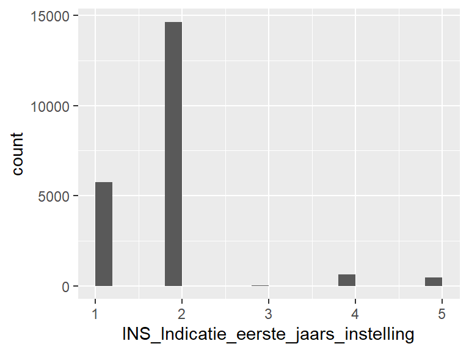

## INS_Indicatie_eerste_jaars_opleiding_en_instelling

| Feature | Result |
| --- | --- |
| Variable type | numeric |
| Number of missing obs. | 0 (0 %) |
| Number of unique values | 3 |
| Median | 2 |
| 1st and 3rd quartiles | 1; 2 |
| Min. and max. | 1; 5 |

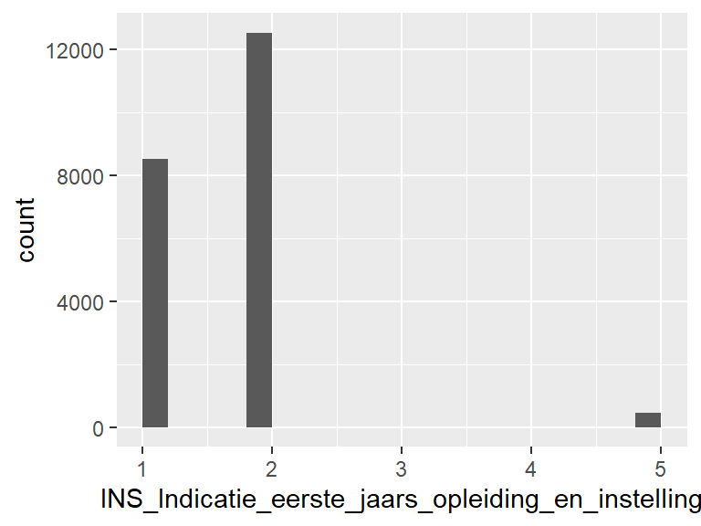

## INS_Eerste_jaar_opleiding_en_instelling

| Feature | Result |
| --- | --- |
| Variable type | numeric |
| Number of missing obs. | 0 (0 %) |
| Number of unique values | 13 |
| Median | 2017 |
| 1st and 3rd quartiles | 2013; 2019 |
| Min. and max. | 2010; 2022 |

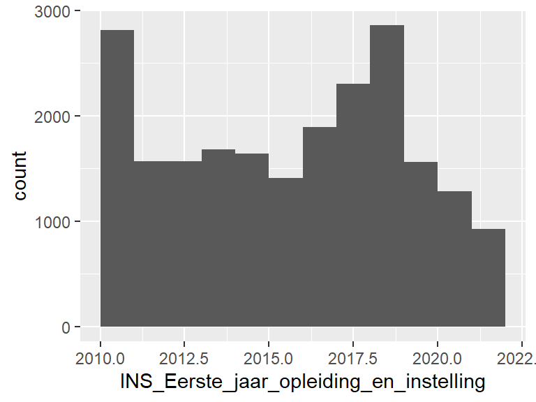

## INS_Eerste_jaar_hoger_onderwijs

| Feature | Result |
| --- | --- |
| Variable type | numeric |
| Number of missing obs. | 0 (0 %) |
| Number of unique values | 41 |
| Median | 2014 |
| 1st and 3rd quartiles | 2011; 2018 |
| Min. and max. | 1978; 2022 |

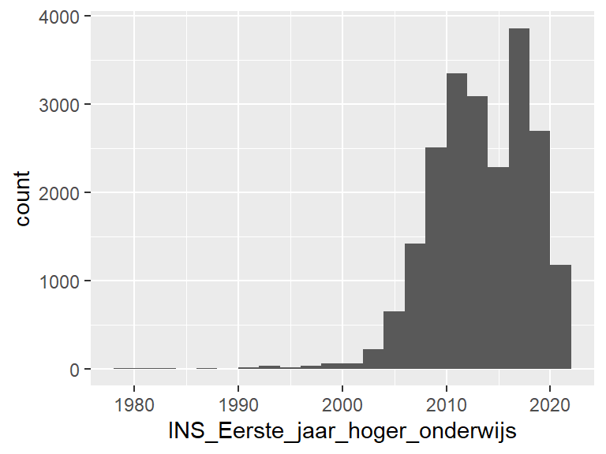

## INS_Eerste_jaar_soort_hoger_onderwijs

| Feature | Result |
| --- | --- |
| Variable type | numeric |
| Number of missing obs. | 0 (0 %) |
| Number of unique values | 40 |
| Median | 2015 |
| 1st and 3rd quartiles | 2011; 2018 |
| Min. and max. | 1978; 2022 |

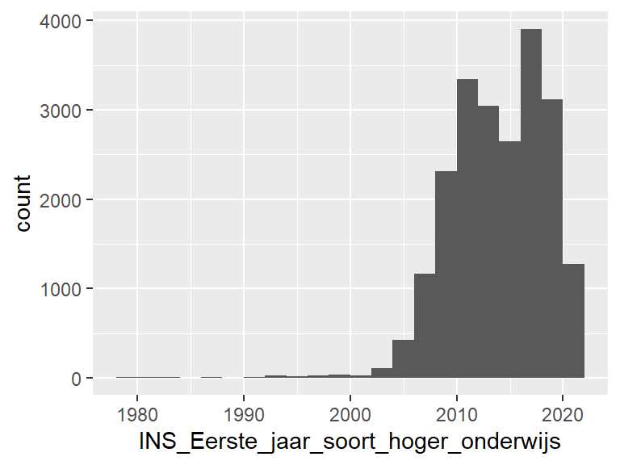

## INS_Vooropleiding_voor_HO_code

| Feature | Result |
| --- | --- |
| Variable type | numeric |
| Number of missing obs. | 0 (0 %) |
| Number of unique values | 25 |
| Median | 404 |
| 1st and 3rd quartiles | 402; 411 |
| Min. and max. | 0; 506 |

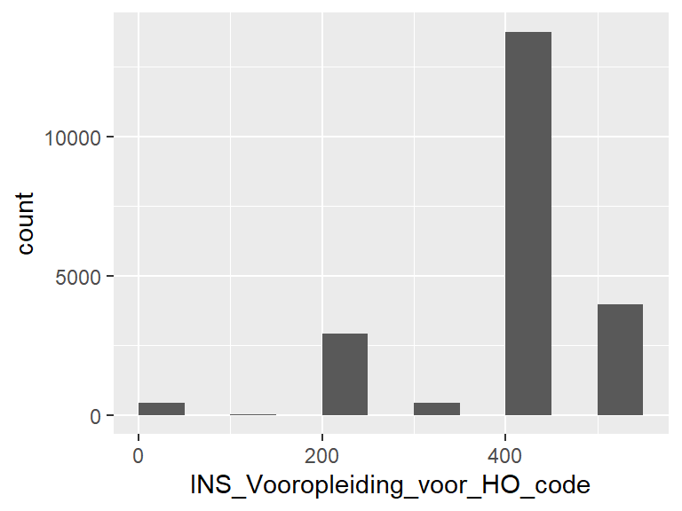

## INS_Vooropleiding_voor_HO_cat

| Feature | Result |
| --- | --- |
| Variable type | character |
| Number of missing obs. | 425 (1.98 %) |
| Number of unique values | 5 |
| Mode | “vwo” |

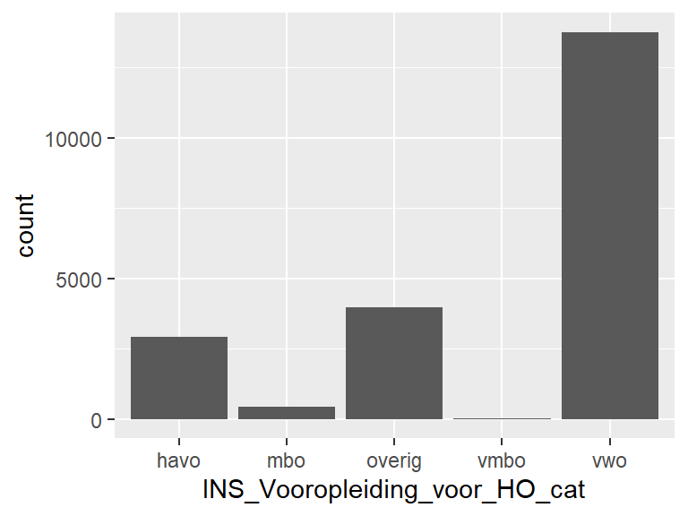

- Observed factor levels: "havo", "mbo", "overig", "vmbo", "vwo".

## INS_Vooropleiding_voor_HO_jaar

| Feature | Result |
| --- | --- |
| Variable type | numeric |
| Number of missing obs. | 442 (2.06 %) |
| Number of unique values | 41 |
| Median | 2013 |
| 1st and 3rd quartiles | 2009; 2016 |
| Min. and max. | 1976; 2021 |

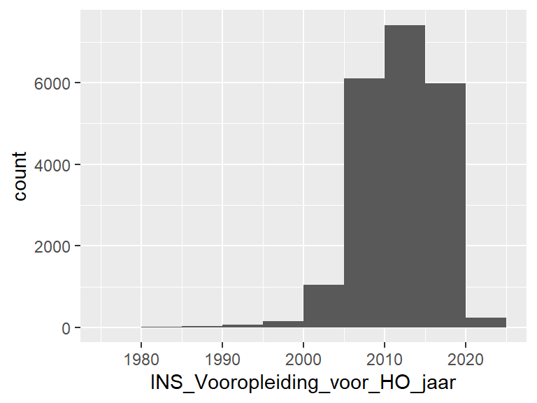

## INS_Vooropleiding_voor_HO_BRIN

| Feature | Result |
| --- | --- |
| Variable type | character |
| Number of missing obs. | 4696 (21.83 %) |
| Number of unique values | 508 |
| Mode | “25PZ” |

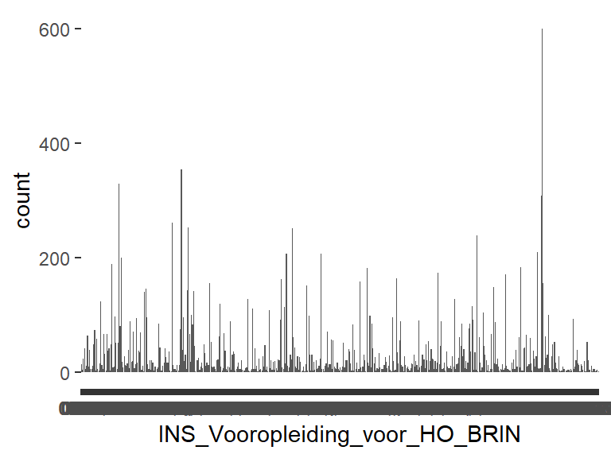

- Observed factor levels: "00AH", "00AQ", "00BD", "00CB", "00GT", …, "30UB", "30WH", "31EX", "31JW", "31LV" (498 values omitted).

## INS_Vooropleiding_binnen_HO_code

| Feature | Result |
| --- | --- |
| Variable type | numeric |
| Number of missing obs. | 0 (0 %) |
| Number of unique values | 45 |
| Median | 0 |
| 1st and 3rd quartiles | 0; 903 |
| Min. and max. | 0; 1206 |

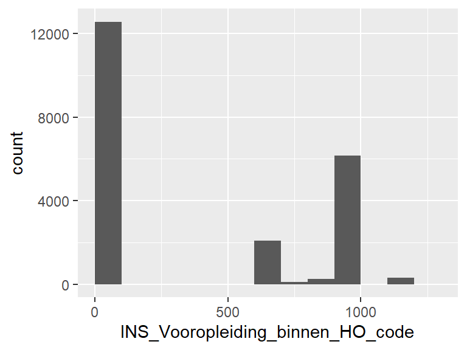

## INS_Vooropleiding_binnen_HO_cat

| Feature | Result |
| --- | --- |
| Variable type | character |
| Number of missing obs. | 12559 (58.39 %) |
| Number of unique values | 7 |
| Mode | “wo-ba” |

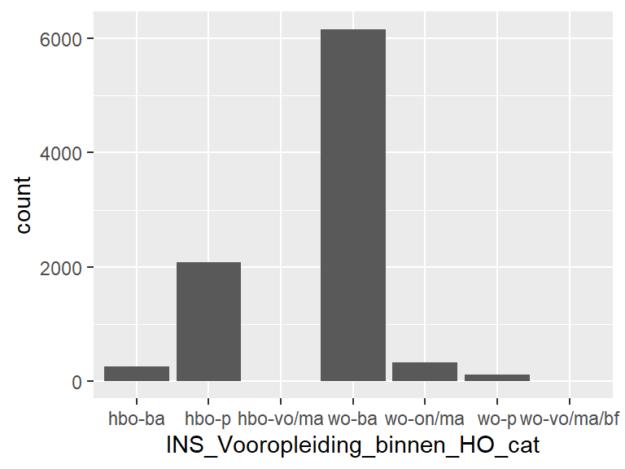

- Observed factor levels: "hbo-ba", "hbo-p", "hbo-vo/ma", "wo-ba", "wo-on/ma", "wo-p", "wo-vo/ma/bf".

## INS_Vooropleiding_binnen_HO_jaar

| Feature | Result |
| --- | --- |
| Variable type | numeric |
| Number of missing obs. | 12559 (58.39 %) |
| Number of unique values | 34 |
| Median | 2014 |
| 1st and 3rd quartiles | 2012; 2017 |
| Min. and max. | 1982; 2021 |

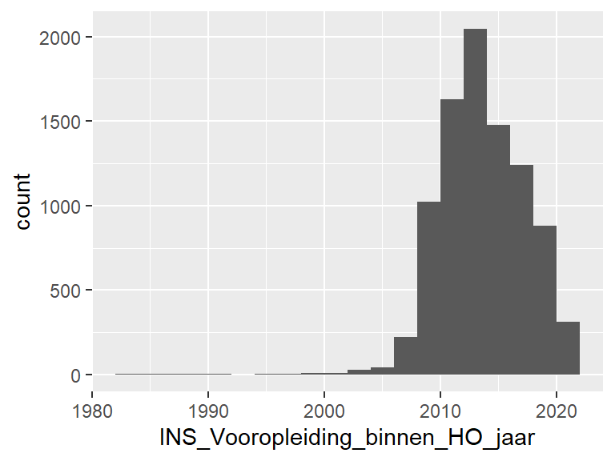

## INS_Vooropleiding_binnen_HO_BRIN

| Feature | Result |
| --- | --- |
| Variable type | character |
| Number of missing obs. | 12684 (58.98 %) |
| Number of unique values | 51 |
| Mode | “21PL” |

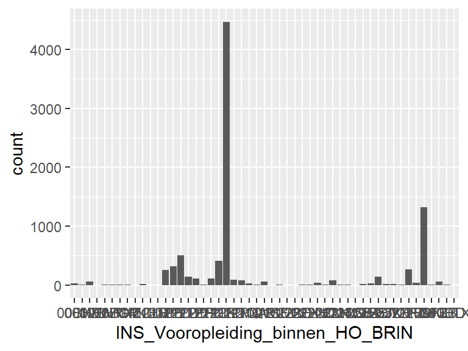

- Observed factor levels: "00BH", "00MF", "01VU", "02BY", "02NR", …, "28DN", "29PZ", "30GB", "30HD", "30TX" (41 values omitted).

## INS_Hoogste_vooropleiding_code_1CHO

| Feature | Result |
| --- | --- |
| Variable type | numeric |
| Number of missing obs. | 0 (0 %) |
| Number of unique values | 63 |
| Median | 502 |
| 1st and 3rd quartiles | 405; 903 |
| Min. and max. | 0; 1206 |

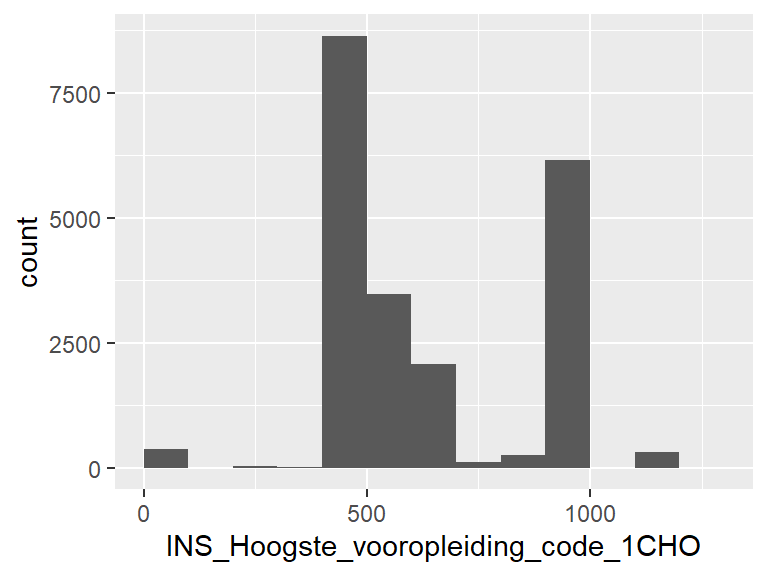

## INS_Hoogste_vooropleiding_cat

| Feature | Result |
| --- | --- |
| Variable type | character |
| Number of missing obs. | 382 (1.78 %) |
| Number of unique values | 11 |
| Mode | “vwo” |

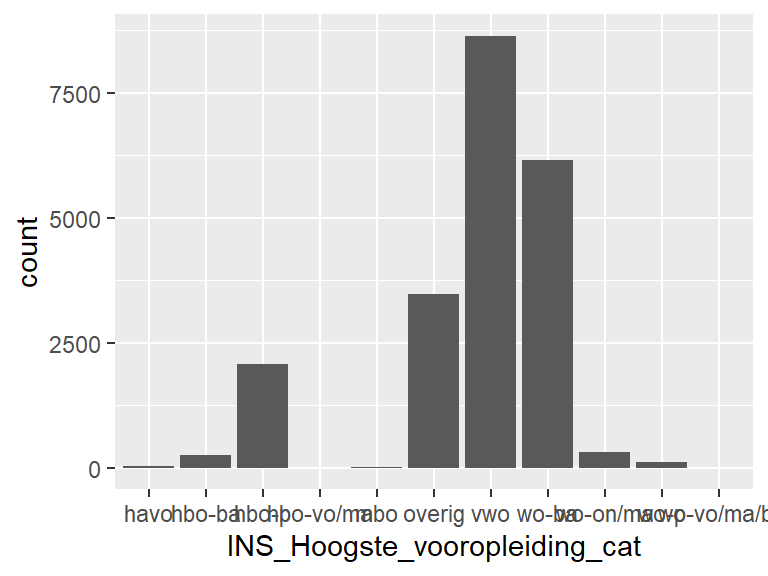

- Observed factor levels: "havo", "hbo-ba", "hbo-p", "hbo-vo/ma", "mbo", …, "vwo", "wo-ba", "wo-on/ma", "wo-p", "wo-vo/ma/bf" (1 values omitted).

## INS_Hoogste_vooropleiding_jaar_1CHO

| Feature | Result |
| --- | --- |
| Variable type | numeric |
| Number of missing obs. | 399 (1.86 %) |
| Number of unique values | 37 |
| Median | 2014 |
| 1st and 3rd quartiles | 2011; 2017 |
| Min. and max. | 1982; 2021 |

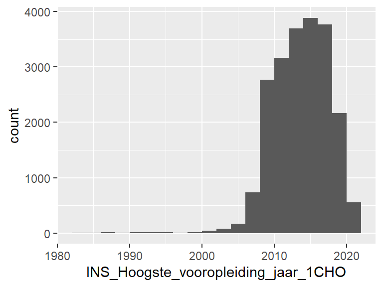

## INS_Hoogste_vooropleiding_BRIN_1CHO

| Feature | Result |
| --- | --- |
| Variable type | character |
| Number of missing obs. | 4127 (19.19 %) |
| Number of unique values | 451 |
| Mode | “21PL” |

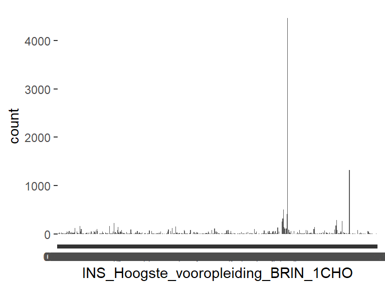

- Observed factor levels: "00AH", "00BD", "00BH", "00CB", "00HI", …, "30UB", "30WH", "31EX", "31JW", "31LV" (441 values omitted).

## INS_Verblijfsjaren_hoger_onderwijs

| Feature | Result |
| --- | --- |
| Variable type | numeric |
| Number of missing obs. | 458 (2.13 %) |
| Number of unique values | 28 |
| Median | 4 |
| 1st and 3rd quartiles | 2; 5 |
| Min. and max. | 1; 28 |

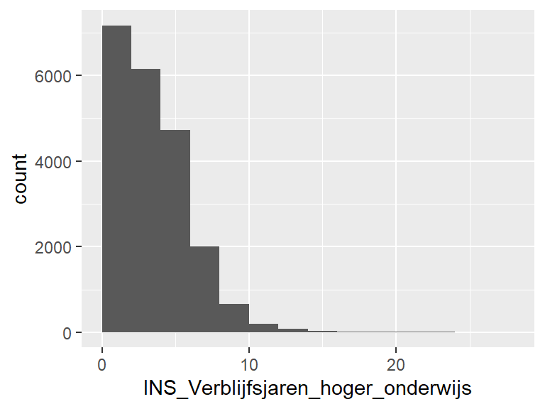

## INS_Verblijfsjaren_wetenschappelijk_onderwijs

| Feature | Result |
| --- | --- |
| Variable type | numeric |
| Number of missing obs. | 458 (2.13 %) |
| Number of unique values | 28 |
| Median | 3 |
| 1st and 3rd quartiles | 2; 5 |
| Min. and max. | 1; 28 |

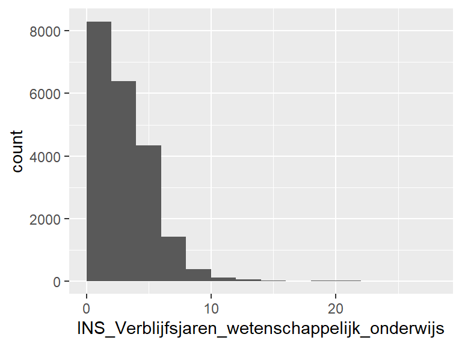

## INS_Inclusief_UvA

- The variable only takes one (non-missing) value: "Nee". The variable contains 0 % missing observations.

## INS_Premaster

- The variable only takes one value: "NA".

## INS_Hoogste_vooropleiding_binnen_HO_code

| Feature | Result |
| --- | --- |
| Variable type | integer |
| Number of missing obs. | 12559 (58.39 %) |
| Number of unique values | 229 |
| Median | 56604 |
| 1st and 3rd quartiles | 35158; 56604 |
| Min. and max. | 590; 81000 |

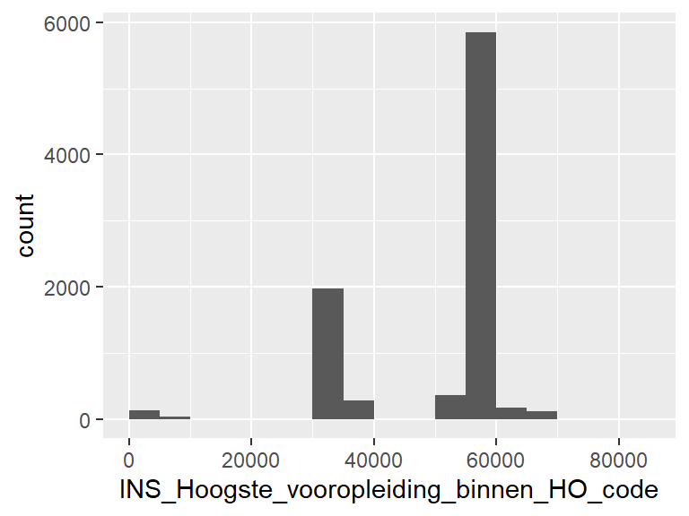

## INS_Faculteit

- The variable only takes one (non-missing) value: "WZD". The variable contains 0 % missing observations.

## INS_Opleidingsvorm_naam

- The variable only takes one (non-missing) value: "Voltijd". The variable contains 0 % missing observations.

## INS_Code_bekostiging

| Feature | Result |
| --- | --- |
| Variable type | character |
| Number of missing obs. | 0 (0 %) |
| Number of unique values | 3 |
| Mode | “J” |

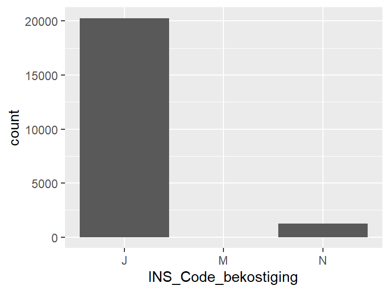

- Observed factor levels: "J", "M", "N".

## INS_Examenresultaat_code

| Feature | Result |
| --- | --- |
| Variable type | numeric |
| Number of missing obs. | 16446 (76.47 %) |
| Number of unique values | 2 |
| Median | 1 |
| 1st and 3rd quartiles | 1; 1 |
| Min. and max. | 1; 9 |

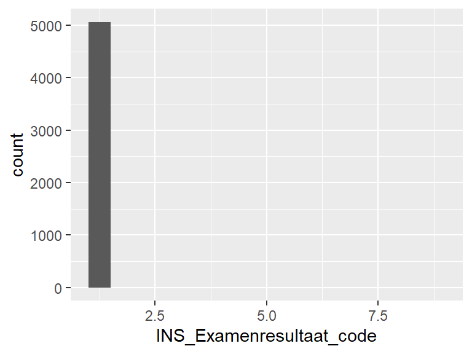

## INS_Opleidingscode_CROHO

- The variable only takes one (non-missing) value: "8". The variable contains 0 % missing observations.

## INS_Code_beeindiging_inschrijving

| Feature | Result |
| --- | --- |
| Variable type | numeric |
| Number of missing obs. | 0 (0 %) |
| Number of unique values | 4 |
| Median | 0 |
| 1st and 3rd quartiles | 0; 0 |
| Min. and max. | 0; 9 |

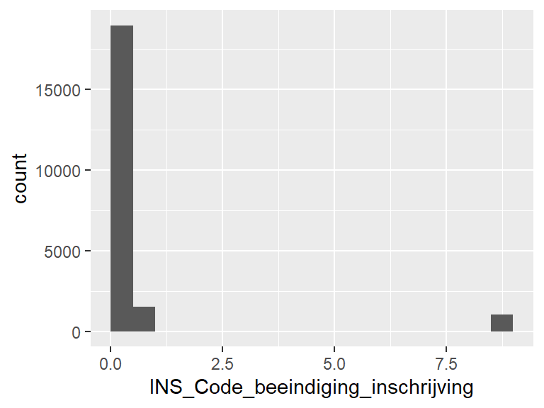

## INS_Type_onderwijs

| Feature | Result |
| --- | --- |
| Variable type | character |
| Number of missing obs. | 0 (0 %) |
| Number of unique values | 2 |
| Mode | “ba” |

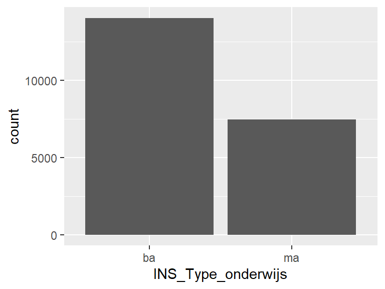

- Observed factor levels: "ba", "ma".

## INS_Diplomajaar

| Feature | Result |
| --- | --- |
| Variable type | numeric |
| Number of missing obs. | 16446 (76.47 %) |
| Number of unique values | 13 |
| Median | 2017 |
| 1st and 3rd quartiles | 2014; 2019 |
| Min. and max. | 2010; 2022 |

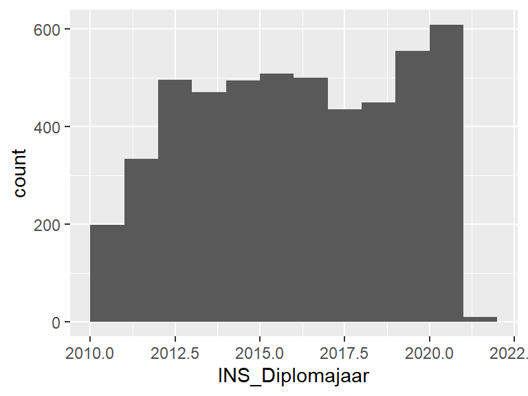

## INS_Diploma_opleidingsfase

| Feature | Result |
| --- | --- |
| Variable type | character |
| Number of missing obs. | 16446 (76.47 %) |
| Number of unique values | 2 |
| Mode | “M” |

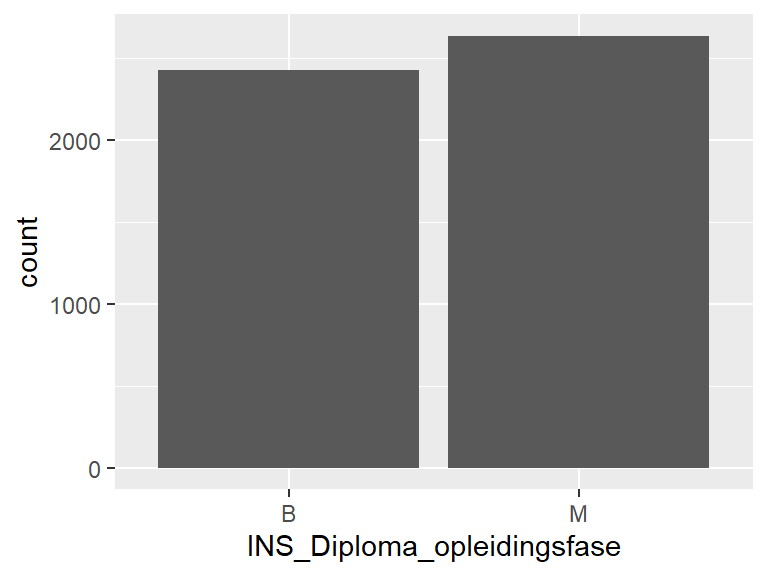

- Observed factor levels: "B", "M".

## INS_Diploma_eerste

| Feature | Result |
| --- | --- |
| Variable type | numeric |
| Number of missing obs. | 16446 (76.47 %) |
| Number of unique values | 2 |
| Median | 1 |
| 1st and 3rd quartiles | 1; 2 |
| Min. and max. | 1; 2 |

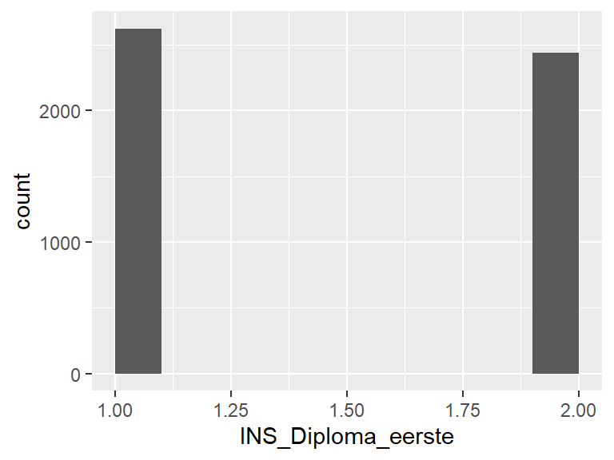

## INS_Diploma_eerste_in_categorie

| Feature | Result |
| --- | --- |
| Variable type | numeric |
| Number of missing obs. | 16446 (76.47 %) |
| Number of unique values | 4 |
| Median | 5 |
| 1st and 3rd quartiles | 3; 5 |
| Min. and max. | 3; 6 |

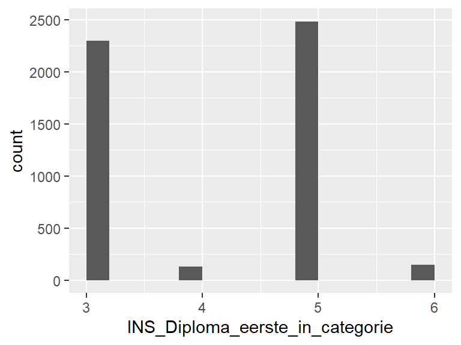

## INS_Diploma_eerste_in_categorie_hoofd_neven

| Feature | Result |
| --- | --- |
| Variable type | numeric |
| Number of missing obs. | 16446 (76.47 %) |
| Number of unique values | 4 |
| Median | 5 |
| 1st and 3rd quartiles | 3; 5 |
| Min. and max. | 3; 6 |

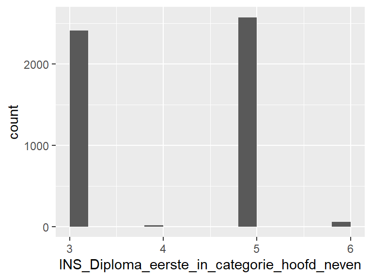

## INS_Diploma_eerste_bij_instelling_hoofd_neven

| Feature | Result |
| --- | --- |
| Variable type | numeric |
| Number of missing obs. | 16446 (76.47 %) |
| Number of unique values | 4 |
| Median | 5 |
| 1st and 3rd quartiles | 3; 5 |
| Min. and max. | 3; 6 |

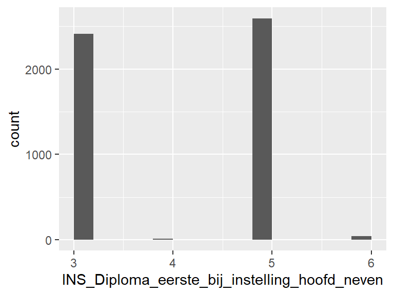

## DEM_Geslacht_code

| Feature | Result |
| --- | --- |
| Variable type | character |
| Number of missing obs. | 0 (0 %) |
| Number of unique values | 3 |
| Mode | “V” |

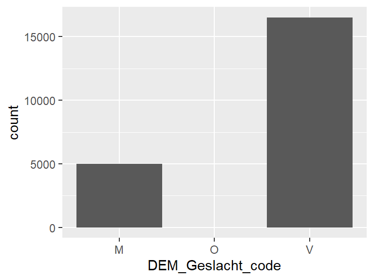

- Observed factor levels: "M", "O", "V".

## DEM_Leeftijd_peildatum_1_oktober

| Feature | Result |
| --- | --- |
| Variable type | numeric |
| Number of missing obs. | 0 (0 %) |
| Number of unique values | 48 |
| Median | 22 |
| 1st and 3rd quartiles | 20; 24 |
| Min. and max. | 14; 63 |

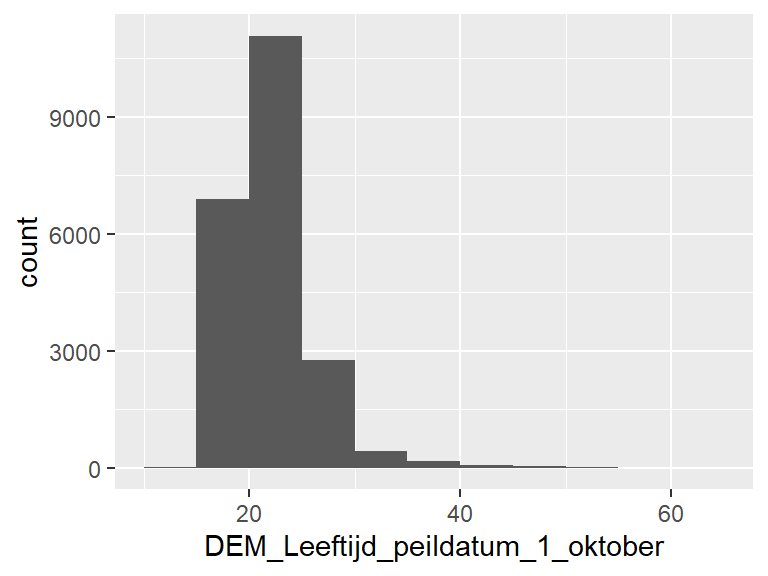

## DEM_Leeftijd_peildatum_1_jan

| Feature | Result |
| --- | --- |
| Variable type | numeric |
| Number of missing obs. | 0 (0 %) |
| Number of unique values | 49 |
| Median | 22 |
| 1st and 3rd quartiles | 20; 25 |
| Min. and max. | 14; 63 |

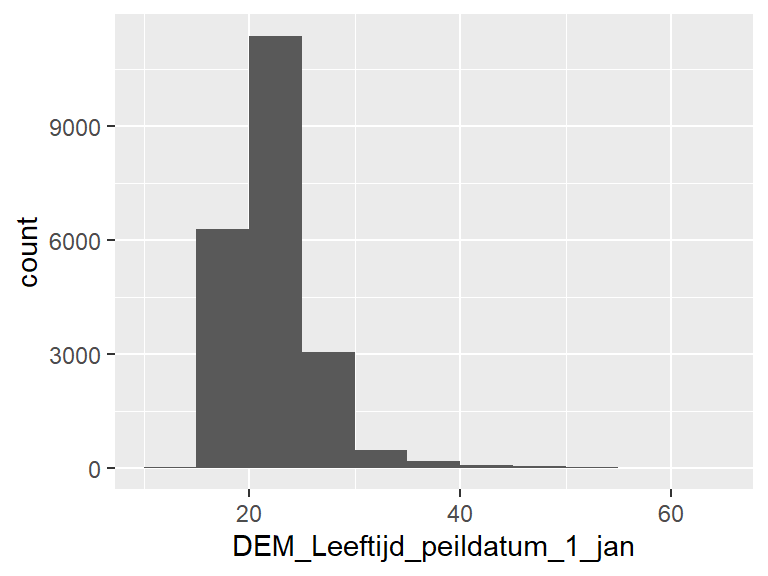

## DEM_Nationaliteit_1

| Feature | Result |
| --- | --- |
| Variable type | numeric |
| Number of missing obs. | 4 (0.02 %) |
| Number of unique values | 89 |
| Median | 1 |
| 1st and 3rd quartiles | 1; 1 |
| Min. and max. | 1; 499 |

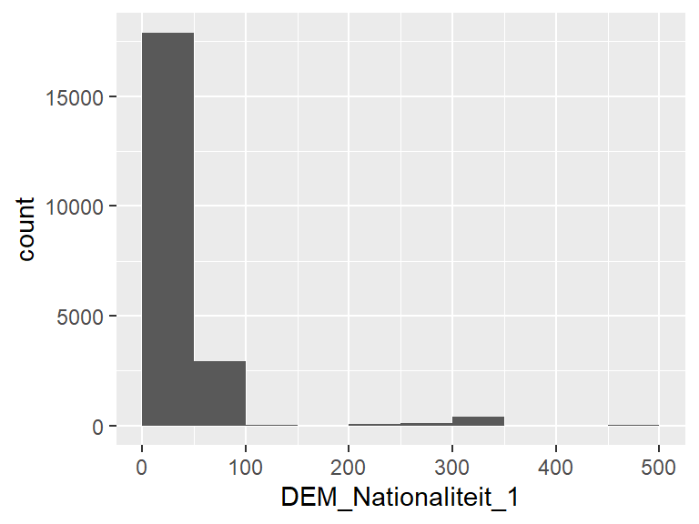

## DEM_Nationaliteit_2

| Feature | Result |
| --- | --- |
| Variable type | numeric |
| Number of missing obs. | 18375 (85.44 %) |
| Number of unique values | 96 |
| Median | 131 |
| 1st and 3rd quartiles | 80; 316 |
| Min. and max. | 28; 499 |

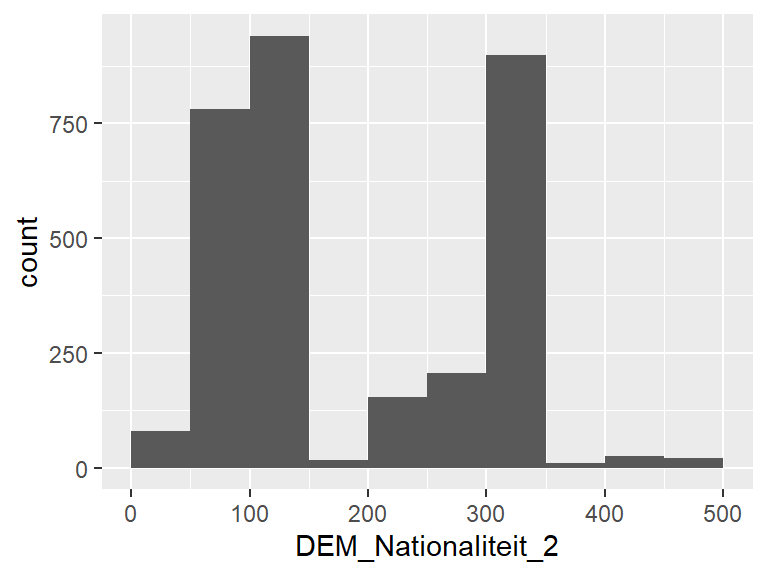

## DEM_Nationaliteit_3

| Feature | Result |
| --- | --- |
| Variable type | integer |
| Number of missing obs. | 21442 (99.7 %) |
| Number of unique values | 12 |
| Median | 339 |
| 1st and 3rd quartiles | 307; 339 |
| Min. and max. | 83; 437 |

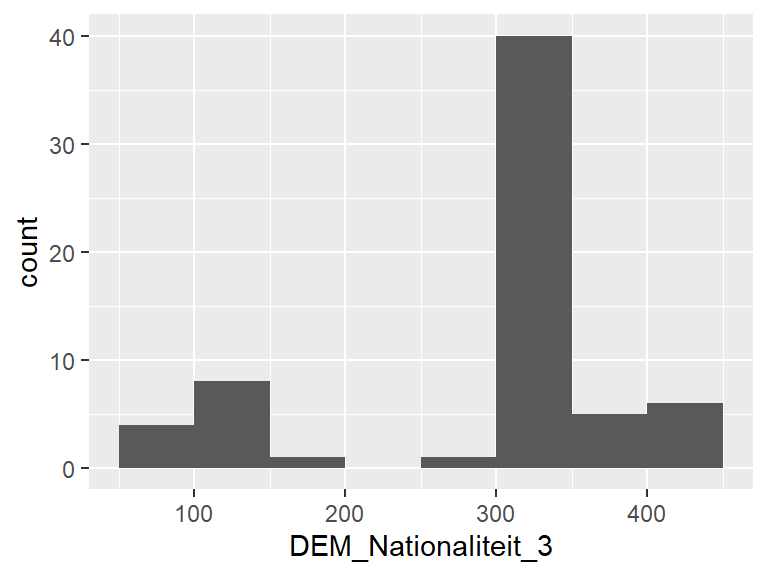

## INS_Postcode_student_1okt_peildatum

| Feature | Result |
| --- | --- |
| Variable type | integer |
| Number of missing obs. | 99 (0.46 %) |
| Number of unique values | 1200 |
| Median | 1183 |
| 1st and 3rd quartiles | 1065; 1824 |
| Min. and max. | 10; 9766 |

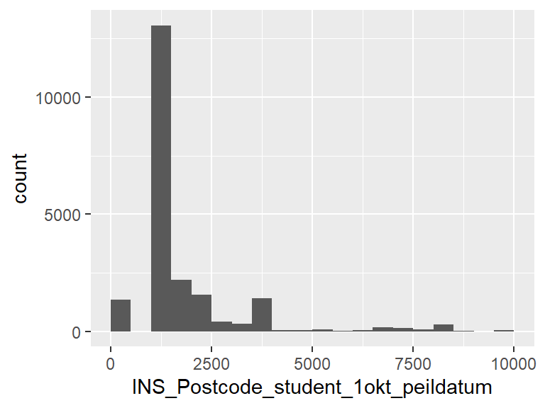

## INS_Vooropleiding_voor_HO_gem_cijfer

| Feature | Result |
| --- | --- |
| Variable type | numeric |
| Number of missing obs. | 7359 (34.22 %) |
| Number of unique values | 30 |
| Median | 65 |
| 1st and 3rd quartiles | 63; 69 |
| Min. and max. | 57; 86 |

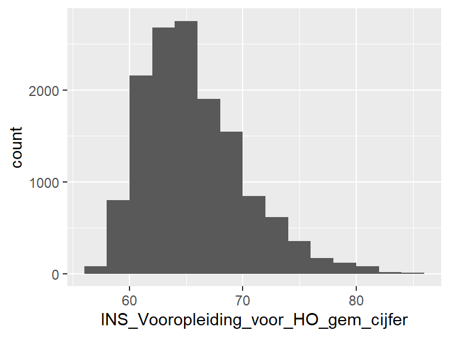

## INS_Datum_inschrijving

| Feature | Result |
| --- | --- |
| Variable type | Date |
| Number of missing obs. | 0 (0 %) |
| Number of unique values | 62 |
| Mode | “2022-09-01” |
| Min. and max. | 2011-09-01; 2022-11-01 |
| 1st and 3rd quartiles | 2014-09-01; 2020-09-01 |

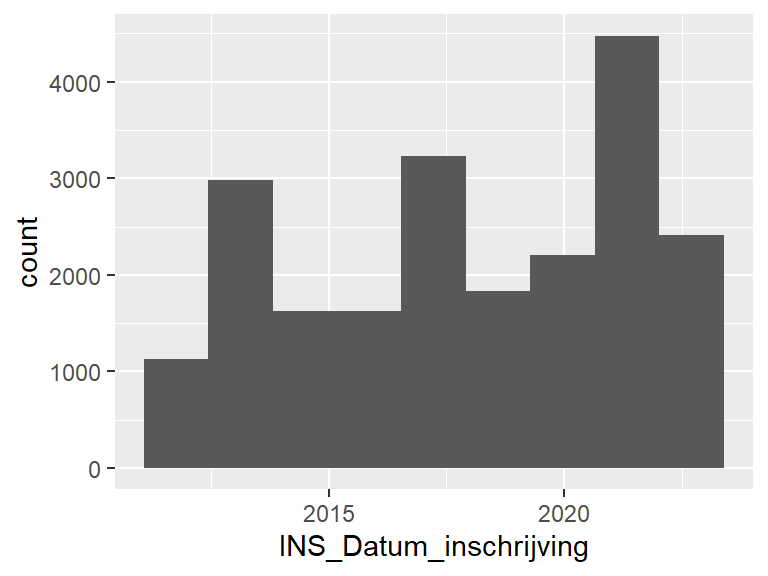

## INS_Datum_uitschrijving

| Feature | Result |
| --- | --- |
| Variable type | Date |
| Number of missing obs. | 0 (0 %) |
| Number of unique values | 128 |
| Mode | “2023-08-31” |
| Min. and max. | 2011-09-30; 2023-08-31 |
| 1st and 3rd quartiles | 2015-08-31; 2021-08-31 |

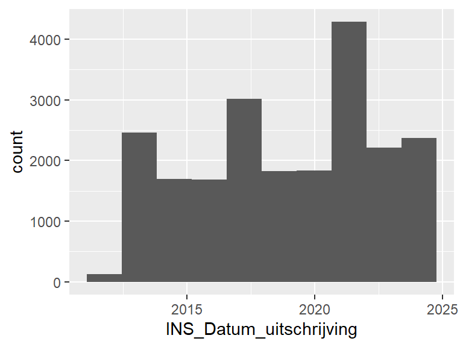

## INS_Verblijfsjaar_type_onderwijs_binnen_HO

| Feature | Result |
| --- | --- |
| Variable type | numeric |
| Number of missing obs. | 458 (2.13 %) |
| Number of unique values | 17 |
| Median | 2 |
| 1st and 3rd quartiles | 1; 3 |
| Min. and max. | 1; 17 |

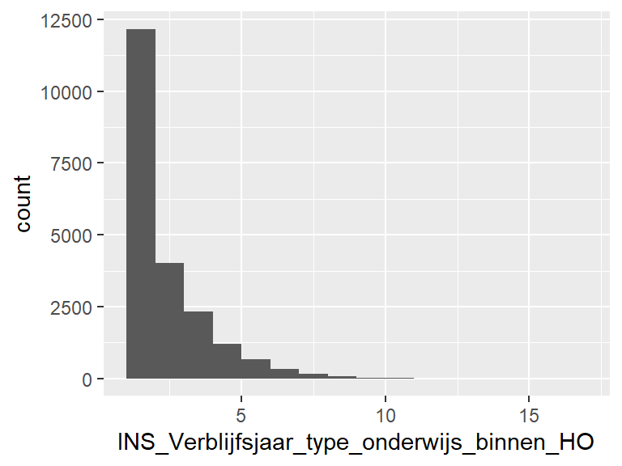

## INS_Postcode_student_voor_HO

| Feature | Result |
| --- | --- |
| Variable type | integer |
| Number of missing obs. | 4622 (21.49 %) |
| Number of unique values | 1494 |
| Median | 1816 |
| 1st and 3rd quartiles | 1244; 3701 |
| Min. and max. | 10; 9989 |

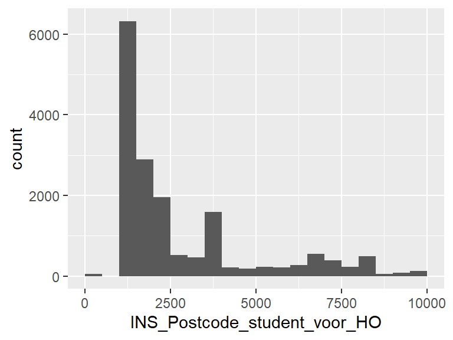

## INS_Maand_inschrijving_van

| Feature | Result |
| --- | --- |
| Variable type | numeric |
| Number of missing obs. | 0 (0 %) |
| Number of unique values | 12 |
| Median | 9 |
| 1st and 3rd quartiles | 9; 9 |
| Min. and max. | 1; 12 |

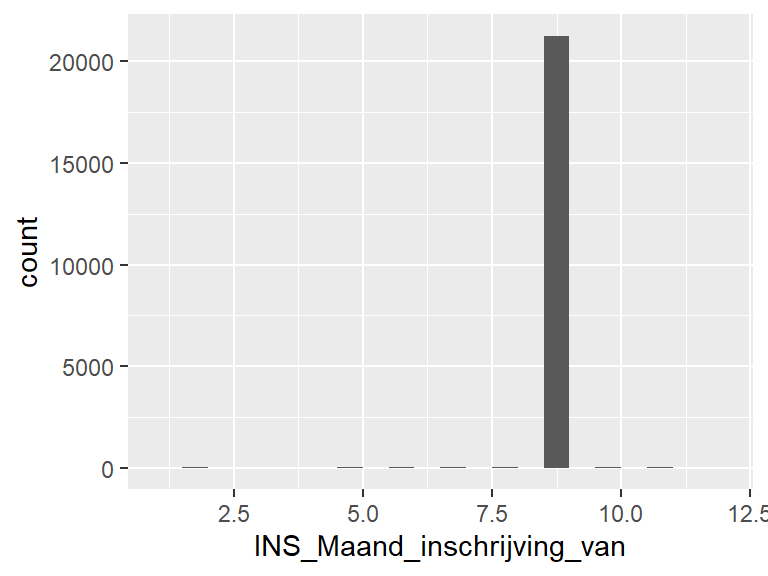

## INS_Maand_inschrijving_tot

| Feature | Result |
| --- | --- |
| Variable type | numeric |
| Number of missing obs. | 19330 (89.88 %) |
| Number of unique values | 12 |
| Median | 4 |
| 1st and 3rd quartiles | 2; 10 |
| Min. and max. | 1; 13 |

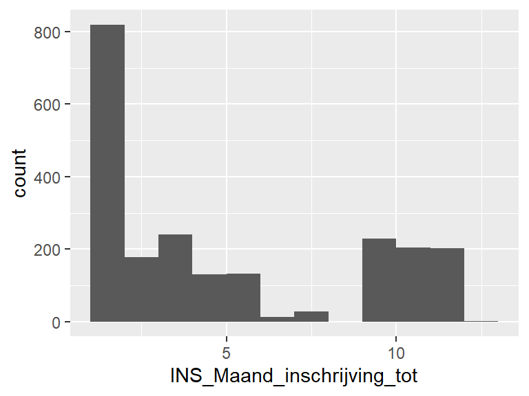

## INS_Maand_examenresultaat

| Feature | Result |
| --- | --- |
| Variable type | numeric |
| Number of missing obs. | 16446 (76.47 %) |
| Number of unique values | 12 |
| Median | 7 |
| 1st and 3rd quartiles | 6; 8 |
| Min. and max. | 1; 12 |

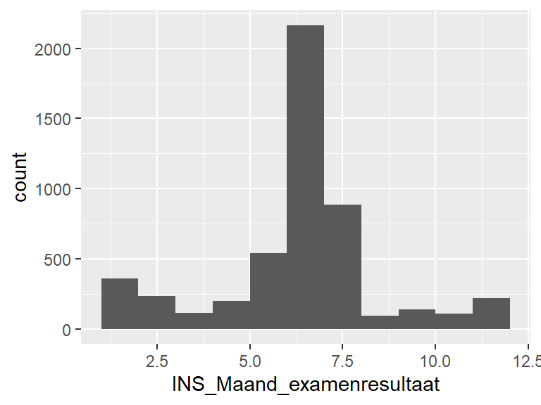

## INS_Croho_sub_onderdeel

- The variable only takes one (non-missing) value: "11". The variable contains 0 % missing observations.

## INS_Verblijfsjaar_type_onderwijs

| Feature | Result |
| --- | --- |
| Variable type | numeric |
| Number of missing obs. | 458 (2.13 %) |
| Number of unique values | 17 |
| Median | 2 |
| 1st and 3rd quartiles | 1; 3 |
| Min. and max. | 1; 17 |

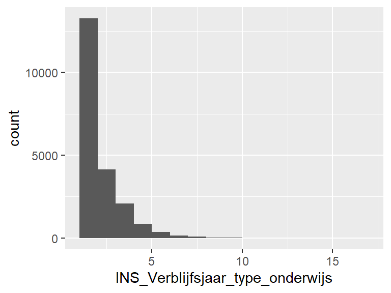

## DEM_Nationaliteit_EER_naam

| Feature | Result |
| --- | --- |
| Variable type | character |
| Number of missing obs. | 0 (0 %) |
| Number of unique values | 3 |
| Mode | “NL” |

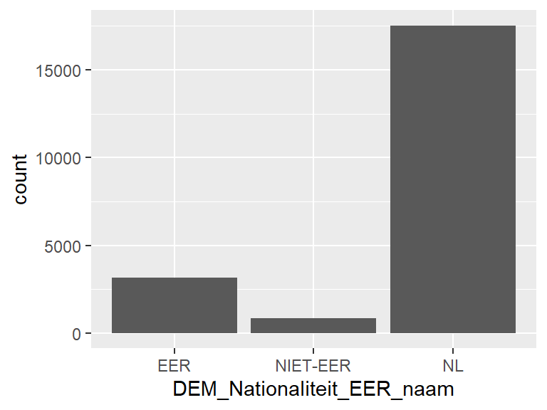

- Observed factor levels: "EER", "NIET-EER", "NL".

## DEM_Indicatie_nationaliteit_EER_actueel

| Feature | Result |
| --- | --- |
| Variable type | logical |
| Number of missing obs. | 0 (0 %) |
| Number of unique values | 2 |
| Mode | “FALSE” |

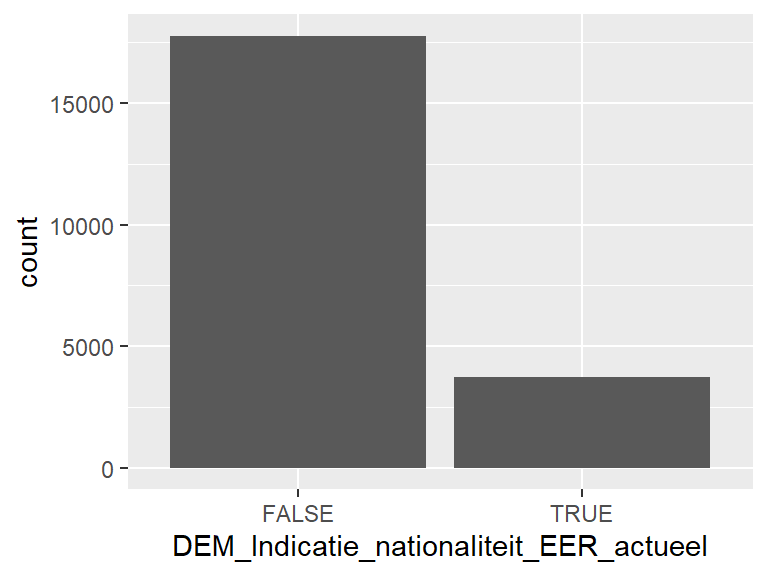

## DEM_Indicatie_nationaliteit_EER_peildatum

| Feature | Result |
| --- | --- |
| Variable type | logical |
| Number of missing obs. | 0 (0 %) |
| Number of unique values | 2 |
| Mode | “TRUE” |

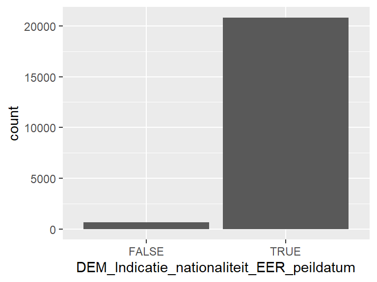

## DEM_Indicatie_internationale_student

| Feature | Result |
| --- | --- |
| Variable type | logical |
| Number of missing obs. | 0 (0 %) |
| Number of unique values | 2 |
| Mode | “TRUE” |

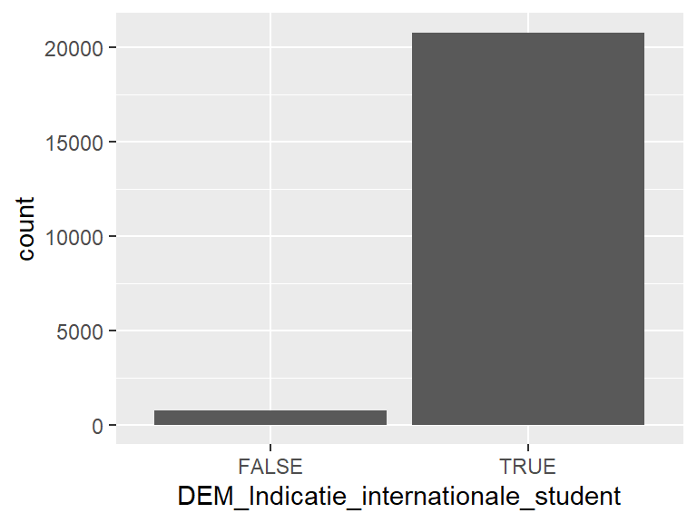

## OPL_Code_actueel

- The variable only takes one (non-missing) value: "60002". The variable contains 0 % missing observations.

## INS_Vooropleiding_binnen_HO_sector

| Feature | Result |
| --- | --- |
| Variable type | character |
| Number of missing obs. | 0 (0 %) |
| Number of unique values | 45 |
| Mode | “vooropleiding onbekend” |

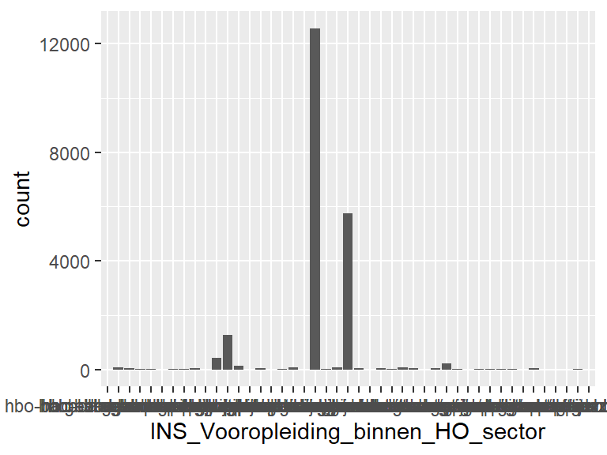

- Observed factor levels: "hbo-ba algemeen", "hbo-ba economie", "hbo-ba gedrag en maatschappij", "hbo-ba gezondheidszorg", "hbo-ba onderwijs", …, "wo-p gezondheidszorg", "wo-p natuur", "wo-p recht", "wo-p taal en cultuur", "wo-vo/ma/bf gezondheidszorg" (35 values omitted).